# Trump's Tweets

## Here's an interesting project I did for class where I worked with the Twitter API in order to analyze Donald Trump's tweets.

```python
# Run this cell to set up your notebook
import csv
import numpy as np
import pandas as pd
import matplotlib.pyplot as plt
import zipfile
import json
import pprint

# Ensure that Pandas shows at least 280 characters in columns, so we can see full tweets
pd.set_option('max_colwidth', 280)

%matplotlib inline
plt.style.use('fivethirtyeight')
import seaborn as sns
sns.set()
sns.set_context("talk")
import re
```

## Getting the data

The starting point and a key aspect of any data science project is getting the data. To get Twitter data, Twitter conveniently provides a developer API using which we can scrape data. I used this API to create a JSON which was used as our dataset.

Start by running the following cells, which will download and then load Donald Trump's most recent tweets.

```python
# Download the dataset
from utils import fetch_and_cache
data_url = 'https://cims.nyu.edu/~policast/recent_tweets.json'
file_name = 'realdonaldtrump_recent_tweets.json'

dest_path = fetch_and_cache(data_url=data_url, file=file_name)
print(f'Located at {dest_path}')
```

```
Using version already downloaded: Mon Oct  7 20:53:32 2019
MD5 hash of file: 216176fb098cd5d6b40b373b98bd3e6d
Located at data/realdonaldtrump_recent_tweets.json
```

```python
def load_tweets(path):
    """Loads tweets that have previously been saved.

    Calling load_tweets(path) after save_tweets(tweets, path)
    will produce the same list of tweets.

    Args:
        path (str): The place where the tweets were be saved.

    Returns:
        list: A list of Dictionary objects, each representing one tweet."""

    with open(path, "rb") as f:
        import json
        return json.load(f)
```

```python
trump_tweets = load_tweets(dest_path)
```

If everything is working correctly correctly this should load roughly the last 3000 tweets by `realdonaldtrump`.

```python
assert 2000 <= len(trump_tweets) <= 4000
```

```python
print(len(trump_tweets))
oldest_month = 10 #October
```

```
3214
```

*My teacher had access to the older tweets which he provided for us*

What if we want to access Donald Trump's old tweets?  
Unfortunately, you cannot download old tweets using the public Twitter APIs. Fortunately, we have a snapshot of earlier tweets of Donald Trump that we can combine with the newer data that you downloaded

We will again use the `fetch_and_cache` utility to download the dataset.

```python
# Download the dataset
from utils import fetch_and_cache
data_url = 'https://cims.nyu.edu/~policast/old_trump_tweets.json.zip'
file_name = 'old_trump_tweets.json.zip'

dest_path = fetch_and_cache(data_url=data_url, file=file_name)
print(f'Located at {dest_path}')
```

```
Using version already downloaded: Mon Oct  7 20:53:32 2019
MD5 hash of file: b6e33874de91d1a40207cdf9f9b51a09
Located at data/old_trump_tweets.json.zip
```

Finally, we we will load the tweets directly from the compressed file without decompressing it first.

```python
my_zip = zipfile.ZipFile(dest_path, 'r')
with my_zip.open("old_trump_tweets.json", "r") as f:
    old_trump_tweets = json.load(f)
```

This data is formatted identically to the recent tweets we just downloaded:

```python
print(old_trump_tweets[0])
```

```
{'created_at': 'Wed Oct 12 14:00:48 +0000 2016', 'id': 786204978629185536, 'id_str': '786204978629185536', 'text': 'PAY TO PLAY POLITICS. \n#CrookedHillary https://t.co/wjsl8ITVvk', 'truncated': False, 'entities': {'hashtags': [{'text': 'CrookedHillary', 'indices': [23, 38]}], 'symbols': [], 'user_m…
```

As a dictionary we can also list the keys:

```python
old_trump_tweets[0].keys()
```

```
dict_keys(['created_at', 'id', 'id_str', 'text', 'truncated', 'entities', 'extended_entities', 'source', 'in_reply_to_status_id', 'in_reply_to_status_id_str', 'in_reply_to_user_id', 'in_reply_to_user_id_str', 'in_reply_to_screen_name', 'user', 'geo', 'coordinates', 'place', 'contributors', 'is_quote…
```

Now we're going to merge the `old_trump_tweets` and the `trump_tweets` we downloaded from twitter into one giant list of tweets.

```python
all_tweets = trump_tweets + old_trump_tweets
```

Here I construct a DataFrame called `trump` containing all the tweets stored in `all_tweets`. The index of the dataframe is the ID of each tweet (looks something like `907698529606541312`). It has these columns:

- `time`: The time the tweet was created encoded as a datetime object. (Use `pd.to_datetime` to encode the timestamp.)
- `source`: The source device of the tweet.
- `text`: The text of the tweet.
- `retweet_count`: The retweet count of the tweet.

```python
trump = pd.DataFrame(all_tweets, columns = ['created_at', 'source', 'full_text', 'text', 'retweet_count', 'id'])
trump['created_at'] = pd.to_datetime(trump['created_at'])
trump['text'].fillna(trump['full_text'], inplace = True)
trump.drop('full_text', axis = 1, inplace = True)
trump.rename(columns = {'created_at': 'time'}, inplace = True)
trump.set_index('id', inplace = True)
trump.head(50)
```

| id | time | source | text | retweet_count |
| --- | --- | --- | --- | --- |
| 1052233253040640001 | 2018-10-16 16:22:11+00:00 | <a href="http://twitter.com/download/iphone" rel="nofollow">Twitter for iPhone</a> | REGISTER TO https://t.co/0pWiwCHGbh! #MAGA🇺🇸 https://t.co/ACTMe53TZU | 5415 |
| 1052232230972678145 | 2018-10-16 16:18:08+00:00 | <a href="http://twitter.com/download/iphone" rel="nofollow">Twitter for iPhone</a> | RT @WhiteHouse: https://t.co/RNqLpOtS3O | 4478 |
| 1052219253384994816 | 2018-10-16 15:26:33+00:00 | <a href="http://twitter.com/download/iphone" rel="nofollow">Twitter for iPhone</a> | Is it really possible that Bruce Ohr, whose wife Nellie was paid by Simpson and GPS Fusion for work done on the Fake Dossier, and who was used as a Pawn in this whole SCAM (WITCH HUNT), is still worki… | 13103 |
| 1052217314463100928 | 2018-10-16 15:18:51+00:00 | <a href="http://twitter.com/download/iphone" rel="nofollow">Twitter for iPhone</a> | “Conflict between Glen Simpson’s testimony to another House Panel about his contact with Justice Department official Bruce Ohr. Ohr was used by Simpson and Steele as a Back Channel to get (FAKE) Dossi… | 6271 |
| 1052213711295930368 | 2018-10-16 15:04:32+00:00 | <a href="http://twitter.com/download/iphone" rel="nofollow">Twitter for iPhone</a> | “Federal Judge throws out Stormy Danials lawsuit versus Trump. Trump is entitled to full legal fees.” @FoxNews Great, now I can go after Horseface and her 3rd rate lawyer in the Great State of Texas. … | 14594 |
| 1052200515608690688 | 2018-10-16 14:12:06+00:00 | <a href="http://twitter.com/download/iphone" rel="nofollow">Twitter for iPhone</a> | Incredible number just out, 7,036,000 job openings. Astonishing - it’s all working! Stock Market up big on tremendous potential of USA. Also, Strong Profits. We are Number One in World, by far! | 13944 |
| 1052186219696803841 | 2018-10-16 13:15:18+00:00 | <a href="http://twitter.com/download/iphone" rel="nofollow">Twitter for iPhone</a> | For the record, I have no financial interests in Saudi Arabia (or Russia, for that matter). Any suggestion that I have is just more FAKE NEWS (of which there is plenty)! | 13402 |
| 1052184484941049857 | 2018-10-16 13:08:24+00:00 | <a href="http://twitter.com/download/iphone" rel="nofollow">Twitter for iPhone</a> | “8X more new manufacturing jobs now than with Obama.” @FoxNews @cvpayne | 10397 |
| 1052183647552491521 | 2018-10-16 13:05:04+00:00 | <a href="http://twitter.com/download/iphone" rel="nofollow">Twitter for iPhone</a> | The United States has strongly informed the President of Honduras that if the large Caravan of people heading to the U.S. is not stopped and brought back to Honduras, no more money or aid will be give… | 27494 |
| 1052181272137801728 | 2018-10-16 12:55:38+00:00 | <a href="http://twitter.com/download/iphone" rel="nofollow">Twitter for iPhone</a> | “Op-Ed praises Trump Administrations efforts at the Border.” @FoxNews The Washington Examiner States, “Finally, the government has taken steps to stop releasing unaccompanied minors to criminals and t… | 9139 |
| 1052173526919196672 | 2018-10-16 12:24:51+00:00 | <a href="http://twitter.com/download/iphone" rel="nofollow">Twitter for iPhone</a> | Thank you to the Cherokee Nation for revealing that Elizabeth Warren, sometimes referred to as Pocahontas, is a complete and total Fraud! | 20549 |
| 1052171444082360320 | 2018-10-16 12:16:35+00:00 | <a href="http://twitter.com/download/iphone" rel="nofollow">Twitter for iPhone</a> | Now that her claims of being of Indian heritage have turned out to be a scam and a lie, Elizabeth Warren should apologize for perpetrating this fraud against the American Public. Harvard called her “a… | 17172 |
| 1052168909665824769 | 2018-10-16 12:06:31+00:00 | <a href="http://twitter.com/download/iphone" rel="nofollow">Twitter for iPhone</a> | Pocahontas (the bad version), sometimes referred to as Elizabeth Warren, is getting slammed. She took a bogus DNA test and it showed that she may be 1/1024, far less than the average American. Now Che… | 19803 |
| 1051992718807830529 | 2018-10-16 00:26:23+00:00 | <a href="http://twitter.com/download/iphone" rel="nofollow">Twitter for iPhone</a> | TOGETHER, WE WILL PREVAIL! https://t.co/C1TLMVkDmt | 16799 |
| 1051984061860904960 | 2018-10-15 23:51:59+00:00 | <a href="http://twitter.com/download/iphone" rel="nofollow">Twitter for iPhone</a> | Open enrollment starts today on lower-priced Medicare Advantage plans so loved by our great seniors. Crazy Bernie and his band of Congressional Dems will outlaw these plans. Disaster! | 18535 |
| 1051962675255603200 | 2018-10-15 22:27:00+00:00 | <a href="http://twitter.com/download/iphone" rel="nofollow">Twitter for iPhone</a> | RT @WhiteHouse: Thank you to the law enforcement, first responders, and state, local, and Federal officials who are helping in recovery eff… | 9209 |
| 1051956730156994560 | 2018-10-15 22:03:23+00:00 | <a href="http://twitter.com/download/iphone" rel="nofollow">Twitter for iPhone</a> | RT @WhiteHouse: "First responders, @fema, the job they've done is incredible," President @realDonaldTrump said as he toured damage from #Hu… | 8230 |
| 1051861686842474496 | 2018-10-15 15:45:43+00:00 | <a href="http://twitter.com/download/iphone" rel="nofollow">Twitter for iPhone</a> | Just arrived in Florida. Also thinking about our GREAT Alabama farmers and our many friends in North and South Carolina today. We are with you! | 12642 |
| 1051832118165139458 | 2018-10-15 13:48:13+00:00 | <a href="http://twitter.com/download/iphone" rel="nofollow">Twitter for iPhone</a> | On our way to Florida and Georgia! | 9172 |
| 1051814214212485120 | 2018-10-15 12:37:05+00:00 | <a href="http://twitter.com/download/iphone" rel="nofollow">Twitter for iPhone</a> | Just spoke to the King of Saudi Arabia who denies any knowledge of whatever may have happened “to our Saudi Arabian citizen.” He said that they are working closely with Turkey to find answer. I am imm… | 21058 |
| 1051811228362919938 | 2018-10-15 12:25:13+00:00 | <a href="http://twitter.com/download/iphone" rel="nofollow">Twitter for iPhone</a> | Will be leaving for Florida and Georgia with the First Lady to tour the hurricane damage and visit with FEMA, First Responders and Law Enforcement. Maximum effort is taking place, everyone is working … | 11540 |
| 1051807774894624768 | 2018-10-15 12:11:29+00:00 | <a href="http://twitter.com/download/iphone" rel="nofollow">Twitter for iPhone</a> | The crowds at my Rallies are far bigger than they have ever been before, including the 2016 election. Never an empty seat in these large venues, many thousands of people watching screens outside. Enth… | 26919 |
| 1051801524857384960 | 2018-10-15 11:46:39+00:00 | <a href="http://twitter.com/download/iphone" rel="nofollow">Twitter for iPhone</a> | “The only way to shut down the Democrats new Mob Rule strategy is to stop them cold at the Ballot Box. The fight for America’s future is never over!” Ben Shapiro | 25684 |
| 1051604811530072066 | 2018-10-14 22:44:59+00:00 | <a href="http://twitter.com/download/iphone" rel="nofollow">Twitter for iPhone</a> | RT @realDonaldTrump: I will be interviewed on “60 Minutes” tonight at 7:00 P.M., after NFL game. Enjoy! | 12173 |
| 1051561865061502977 | 2018-10-14 19:54:20+00:00 | <a href="http://twitter.com/download/iphone" rel="nofollow">Twitter for iPhone</a> | Thank you to NBC for the correction! https://t.co/L2mX3vREOl | 18630 |
| 1051559539605164034 | 2018-10-14 19:45:05+00:00 | <a href="http://twitter.com/download/iphone" rel="nofollow">Twitter for iPhone</a> | Thank you! https://t.co/CrExOML9Mi | 13437 |
| 1051558072433463297 | 2018-10-14 19:39:16+00:00 | <a href="http://twitter.com/download/iphone" rel="nofollow">Twitter for iPhone</a> | I will be interviewed on “60 Minutes” tonight at 7:00 P.M., after NFL game. Enjoy! | 12173 |
| 1051473226109513728 | 2018-10-14 14:02:07+00:00 | <a href="http://twitter.com/download/iphone" rel="nofollow">Twitter for iPhone</a> | Princess Eugenie of York was a truly beautiful bride yesterday. She has been through so much, and has come out a total winner! | 10324 |
| 1051471737068670977 | 2018-10-14 13:56:12+00:00 | <a href="http://twitter.com/download/iphone" rel="nofollow">Twitter for iPhone</a> | NBC News has totally and purposely changed the point and meaning of my story about General Robert E Lee and General Ulysses Grant. Was actually a shoutout to warrior Grant and the great state in which… | 31133 |
| 1051319975795933184 | 2018-10-14 03:53:09+00:00 | <a href="http://twitter.com/download/iphone" rel="nofollow">Twitter for iPhone</a> | Congratulations to Tucker Carlson on the great success of his book, “Ship of Fools.” It just went to NUMBER ONE! | 20299 |
| 1051317348496490496 | 2018-10-14 03:42:43+00:00 | <a href="http://twitter.com/download/iphone" rel="nofollow">Twitter for iPhone</a> | Big day! Pastor Andrew Brunson, who could have spent 35 years in a Turkish prison, was returned safely home to his family today. Met in Oval Office, great people! Then off to Kentucky for a Rally for … | 16963 |
| 1051280606536105984 | 2018-10-14 01:16:43+00:00 | <a href="http://twitter.com/download/iphone" rel="nofollow">Twitter for iPhone</a> | Thank you Kentucky! #MAGA🇺🇸\nhttps://t.co/iCUqrQ91gF https://t.co/xwsa1S2dIU | 12715 |
| 1051217592554323973 | 2018-10-13 21:06:19+00:00 | <a href="http://twitter.com/download/iphone" rel="nofollow">Twitter for iPhone</a> | On my way to Richmond, Kentucky for a MAKE AMERICA GREAT AGAIN rally at 7:00pmE. The crowds are once again, massive. See everyone in a couple of hours! #MAGA https://t.co/D1FYNgW0nL https://t.co/d0VBF… | 9935 |
| 1051213021115285504 | 2018-10-13 20:48:09+00:00 | <a href="http://twitter.com/download/iphone" rel="nofollow">Twitter for iPhone</a> | WELCOME HOME PASTOR ANDREW BRUNSON! https://t.co/HijeAGU1gy | 19782 |
| 1051211563946975233 | 2018-10-13 20:42:22+00:00 | <a href="http://twitter.com/download/iphone" rel="nofollow">Twitter for iPhone</a> | https://t.co/uIaENHQoPK | 11548 |
| 1051168800324931584 | 2018-10-13 17:52:26+00:00 | <a href="http://twitter.com/download/iphone" rel="nofollow">Twitter for iPhone</a> | Heading to the Great State of Kentucky - Big Rally for Congressman Andy Barr - Fantastic guy, need his vote for MAGA! Strong on Crime, Tax Cuts, Military, Vets &amp; 2nd A. His opponent will NEVER vot… | 15974 |
| 1051166436029358081 | 2018-10-13 17:43:02+00:00 | <a href="http://twitter.com/download/iphone" rel="nofollow">Twitter for iPhone</a> | Highly respected Congressman Keith Rothfus (R) of Pennsylvania is in the fight of his life because the Dems changed the District Map. He must win. Strong on crime, borders, big tax &amp; reg cuts, Mil… | 26262 |
| 1051156386179141632 | 2018-10-13 17:03:06+00:00 | <a href="http://twitter.com/download/iphone" rel="nofollow">Twitter for iPhone</a> | “From a Turkish prison to the White House in 24 hours.” Kristin Fisher of @FoxNews Very cool! | 14914 |
| 1051114825391239169 | 2018-10-13 14:17:57+00:00 | <a href="http://twitter.com/download/iphone" rel="nofollow">Twitter for iPhone</a> | There was NO DEAL made with Turkey for the release and return of Pastor Andrew Brunson. I don’t make deals for hostages. There was, however, great appreciation on behalf of the United States, which wi… | 24399 |
| 1051111923788513281 | 2018-10-13 14:06:26+00:00 | <a href="http://twitter.com/download/iphone" rel="nofollow">Twitter for iPhone</a> | Pastor Andrew Brunson, released by Turkey, will be with me in the Oval Office at 2:30 P.M. (this afternoon). It will be wonderful to see and meet him. He is a great Christian who has been through such… | 17074 |
| 1051103122163204097 | 2018-10-13 13:31:27+00:00 | <a href="http://twitter.com/download/iphone" rel="nofollow">Twitter for iPhone</a> | Happy 243rd Birthday to our GREAT @USNavy! #243NavyBday https://t.co/m1YtoKSHFw | 12602 |
| 1050918295690465280 | 2018-10-13 01:17:01+00:00 | <a href="http://twitter.com/download/iphone" rel="nofollow">Twitter for iPhone</a> | RT @realDonaldTrump: Don’t miss our GREAT @FLOTUS, Melania, on @ABC @ABC2020 tonight at 10pmE. Enjoy! | 11190 |
| 1050906531162677248 | 2018-10-13 00:30:16+00:00 | <a href="http://twitter.com/download/iphone" rel="nofollow">Twitter for iPhone</a> | Beautiful MAKE AMERICA GREAT AGAIN rally in Lebanon, Ohio. Thank you! #ICYMI, watch here: https://t.co/UGQAmARPKR https://t.co/6nsoV8yTx3 | 10569 |
| 1050872423317471232 | 2018-10-12 22:14:44+00:00 | <a href="http://twitter.com/download/iphone" rel="nofollow">Twitter for iPhone</a> | The GREAT football (and lacrosse) player, Jim Brown outside the West Wing of the @WhiteHouse. He is also a tremendous man and mentor to many young people! https://t.co/yo7MxoGL6C | 21356 |
| 1050869299567562752 | 2018-10-12 22:02:19+00:00 | <a href="http://twitter.com/download/iphone" rel="nofollow">Twitter for iPhone</a> | https://t.co/HHTwwbuKa2 | 10325 |
| 1050861279529893888 | 2018-10-12 21:30:27+00:00 | <a href="http://twitter.com/download/iphone" rel="nofollow">Twitter for iPhone</a> | RT @WhiteHouse: https://t.co/IqLBKtgNEf | 8860 |
| 1050832839678353410 | 2018-10-12 19:37:27+00:00 | <a href="http://twitter.com/download/iphone" rel="nofollow">Twitter for iPhone</a> | Happy #NationalFarmersDay! With the recent #USMCA our GREAT FARMERS will do better than ever before!! https://t.co/PMS4z2EScY | 8322 |
| 1050826148131860480 | 2018-10-12 19:10:51+00:00 | <a href="http://twitter.com/download/iphone" rel="nofollow">Twitter for iPhone</a> | Don’t miss our GREAT @FLOTUS, Melania, on @ABC @ABC2020 tonight at 10pmE. Enjoy! | 11190 |
| 1050810652271529984 | 2018-10-12 18:09:17+00:00 | <a href="http://twitter.com/download/iphone" rel="nofollow">Twitter for iPhone</a> | People have no idea how hard Hurricane Michael has hit the great state of Georgia. I will be visiting both Florida and Georgia early next week. We are working very hard on every area and every state t… | 16912 |
| 1050788995377049601 | 2018-10-12 16:43:13+00:00 | <a href="http://twitter.com/download/iphone" rel="nofollow">Twitter for iPhone</a> | PROMISES MADE, PROMISES KEPT! https://t.co/2lk8Fjspe4 | 18420 |

```python
## BEGIN TESTS
assert isinstance(trump, pd.DataFrame)
assert trump.shape[0] < 11000
assert trump.shape[1] >= 4
assert 831846101179314177 in trump.index
assert 753063644578144260 in trump.index
assert all(col in trump.columns for col in ['time', 'source', 'text', 'retweet_count'])
# If you fail these tests, you probably tried to use __dict__ or _json to read in the tweets
assert np.sometrue([('Twitter for iPhone' in s) for s in trump['source'].unique()])
assert isinstance(trump['time'].dtype, pd.core.dtypes.dtypes.DatetimeTZDtype)
assert trump['text'].dtype == np.dtype('O')
assert trump['retweet_count'].dtype == np.dtype('int64')
```

## Tweet Source Analysis

In the following questions, we are going to find out the charateristics of Trump tweets and the devices used for the tweets.

First let's examine the source field:

```python
trump['source'].unique()
```

```
array(['<a href="http://twitter.com/download/iphone" rel="nofollow">Twitter for iPhone</a>',
       '<a href="https://studio.twitter.com" rel="nofollow">Media Studio</a>',
       '<a href="http://twitter.com/#!/download/ipad" rel="nofollow">Twitter for iPad</a>',
       '<a href="http://twitter.com" rel="nofollow">Twitter Web Client</a>',
       '<a href="http://twitter.com/download/android" rel="nofollow">Twitter for Android</a>',
       '<a href="http://instagram.com" rel="nofollow">Instagram</a>',
       '<a href="https://mobile.twitter.com" rel="nofollow">Mobile Web (M5)</a>',
       '<a href="https://ads.twitter.com" rel="nofollow">Twitter Ads</a>',
       '<a href="https://periscope.tv" rel="nofollow">Periscope</a>'],
      dtype=object)
```

Remove the HTML tags from the source field.

```python
trump['source'] = trump['source'].str.replace('<.*">', '')
trump['source'] = trump['source'].str.replace('</a>', '')#TODO
```

```python
from datetime import datetime, timezone
ELEC_DATE = datetime(2016, 11, 8, tzinfo=timezone.utc)
INAUG_DATE = datetime(2017, 1, 20, tzinfo=timezone.utc)
assert set(trump[(trump['time'] > ELEC_DATE) & (trump['time'] < INAUG_DATE) ]['source'].unique()) == set(['Twitter Ads',
 'Twitter Web Client',
 'Twitter for Android',
 'Twitter for iPhone'])
```

We can see in the following plot that there are two device types that are more commonly used

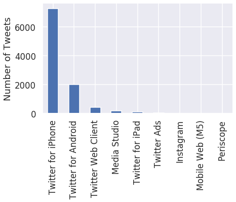

```python
trump['source'].value_counts().plot(kind="bar")
plt.ylabel("Number of Tweets")
```

Let's see if there is a difference in his activity between his devices.

First, we'll take a look at whether Trump's tweets from an Android come at different times than his tweets from an iPhone. Note that Twitter gives us his tweets in the [UTC timezone](https://www.wikiwand.com/en/List_of_UTC_time_offsets) (notice the `+0000` in the first few tweets)

```python
for t in trump_tweets[0:3]:
    print(t['created_at'])
```

```
Tue Oct 16 16:22:11 +0000 2018
Tue Oct 16 16:18:08 +0000 2018
Tue Oct 16 15:26:33 +0000 2018
```

We'll convert the tweet times to US Eastern Time, the timezone of New York and Washington D.C., since those are the places we would expect the most tweet activity from Trump.

```python
trump['est_time'] = (
    trump['time'].dt.tz_convert("EST")
)
trump.head()
```

| id | time | source | text | retweet_count | est_time |
| --- | --- | --- | --- | --- | --- |
| 1052233253040640001 | 2018-10-16 16:22:11+00:00 | Twitter for iPhone | REGISTER TO https://t.co/0pWiwCHGbh! #MAGA🇺🇸 https://t.co/ACTMe53TZU | 5415 | 2018-10-16 11:22:11-05:00 |
| 1052232230972678145 | 2018-10-16 16:18:08+00:00 | Twitter for iPhone | RT @WhiteHouse: https://t.co/RNqLpOtS3O | 4478 | 2018-10-16 11:18:08-05:00 |
| 1052219253384994816 | 2018-10-16 15:26:33+00:00 | Twitter for iPhone | Is it really possible that Bruce Ohr, whose wife Nellie was paid by Simpson and GPS Fusion for work done on the Fake Dossier, and who was used as a Pawn in this whole SCAM (WITCH HUNT), is still worki… | 13103 | 2018-10-16 10:26:33-05:00 |
| 1052217314463100928 | 2018-10-16 15:18:51+00:00 | Twitter for iPhone | “Conflict between Glen Simpson’s testimony to another House Panel about his contact with Justice Department official Bruce Ohr. Ohr was used by Simpson and Steele as a Back Channel to get (FAKE) Dossi… | 6271 | 2018-10-16 10:18:51-05:00 |
| 1052213711295930368 | 2018-10-16 15:04:32+00:00 | Twitter for iPhone | “Federal Judge throws out Stormy Danials lawsuit versus Trump. Trump is entitled to full legal fees.” @FoxNews Great, now I can go after Horseface and her 3rd rate lawyer in the Great State of Texas. … | 14594 | 2018-10-16 10:04:32-05:00 |

Next I add a column called `hour` to the `trump` table which contains the hour of the day as floating point number computed by:

$$ \text{hour} + \frac{\text{minute}}{60} + \frac{\text{second}}{60^2} $$

```python
trump['hour'] = trump['est_time'].apply(lambda x: (x.hour) + (x.minute/60) + (x.second/3600)) #TODO
```

Now I plot this data with the seaborn `distplot` function to examine the distribution over hours of the day in eastern time that trump tweets on each device for the 2 most commonly used devices.

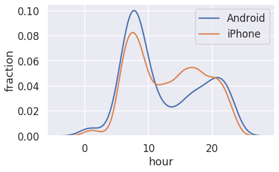

```python
android = trump.loc[(trump['source'] == 'Twitter for Android')]
iphone = trump.loc[(trump['source'] == 'Twitter for iPhone')]
sns.distplot(android['hour'], hist = False, label = 'Android')
sns.distplot(iphone['hour'], hist = False, label = 'iPhone')
plt.ylabel('fraction')
```

According to [this Verge article](https://www.theverge.com/2017/3/29/15103504/donald-trump-iphone-using-switched-android), Donald Trump switched from an Android to an iPhone sometime in March 2017.

Now I created a figure identical to my figure from 4c, except that I now show the results only from 2016. During the campaign, it was theorized that Donald Trump's tweets from Android were written by him personally, and the tweets from iPhone were from his staff. Let's see what the data shows.

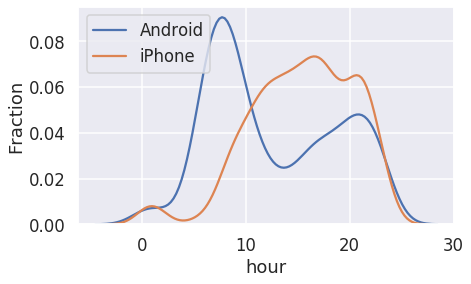

```python
androidboi = android.loc[(android['est_time'] < '2017-01-01 0:00:00') & (android['est_time'] > '2015-12-31 23:59:59')]
iphoneboi = iphone.loc[(iphone['est_time'] < '2017-01-01 0:00:00') & (iphone['est_time'] > '2015-12-31 23:59:59')]
sns.distplot(androidboi['hour'], hist = False, label = 'Android')
sns.distplot(iphoneboi['hour'], hist = False, label = 'iPhone')
plt.ylabel('Fraction')
```

The figure shows that the Iphone tweets were more commonly done during normal work hours and the Android early in the morning supporting the theory that Donald Trump's staff was tweeting from the Iphone.

Let's now look at which device he has used over the entire time period of this dataset.

To examine the distribution of dates we will convert the date to a fractional year that can be plotted as a distribution.

(Code borrowed from https://stackoverflow.com/questions/6451655/python-how-to-convert-datetime-dates-to-decimal-years)

```python
import datetime
def year_fraction(date):
    start = datetime.date(date.year, 1, 1).toordinal()
    year_length = datetime.date(date.year+1, 1, 1).toordinal() - start
    return date.year + float(date.toordinal() - start) / year_length


trump['year'] = trump['time'].apply(year_fraction)
```

Now we use the `sns.distplot` to overlay the distributions of the 2 most frequently used web technologies over the years.

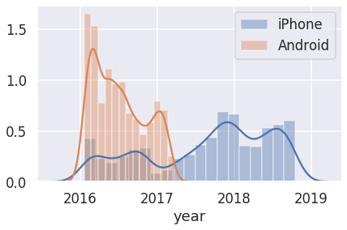

```python
iphonegorl = trump.loc[(trump['source'] == 'Twitter for iPhone')]
androidgorl = trump.loc[(trump['source'] == 'Twitter for Android')]
sns.distplot(iphonegorl['year'], label = 'iPhone')
sns.distplot(androidgorl['year'], label = 'Android')
sircodeaplot = plt.gca()
plt.legend()
```

It turns out that we can use the words in Trump's tweets to calculate a measure of the sentiment of the tweet. For example, the sentence "I love America!" has positive sentiment, whereas the sentence "I hate taxes!" has a negative sentiment. In addition, some words have stronger positive / negative sentiment than others: "I love America." is more positive than "I like America."

I used the [VADER (Valence Aware Dictionary and sEntiment Reasoner)](https://github.com/cjhutto/vaderSentiment) lexicon to analyze the sentiment of Trump's tweets. VADER is a lexicon and rule-based sentiment analysis tool that is specifically attuned to sentiments expressed in social media which is great for our usage.

The VADER lexicon gives the sentiment of individual words.

```python
print(''.join(open("vader_lexicon.txt").readlines()[-100:]))
```

```
withdrawal	0.1	1.57797	[1, -1, 0, -2, -2, 2, -1, 1, 0, 3]
woe	-1.8	0.6	[-3, -2, -2, -2, -1, -1, -2, -1, -2, -2]
woebegone	-2.6	0.66332	[-3, -2, -3, -2, -2, -4, -3, -2, -2, -3]
woebegoneness	-1.1	1.37477	[-3, 0, -1, 1, -1, -4, 0, -1, -1, -1]
woeful	-1.9	0.83066	[-1, -2, -2, -1, -3, -3, -1, -2, -1, -3]
woefully	-1.7	1.48661	[-1, -3, -2, 1, -3, -3, -2, -2, 1, -3]
woefulness	-2.1	0.7	[-3, -2, -2, -1, -2, -3, -3, -1, -2, -2]
woes	-1.9	0.83066	[-2, -2, -2, -1, -2, -3, -3, 0, -2, -2]
woesome	-1.2	1.6	[-2, -3, -2, -1, 0, 3, -2, -2, -1, -2]
won	2.7	0.9	[3, 4, 2, 2, 2, 4, 4, 2, 2, 2]
wonderful	2.7	0.78102	[2, 3, 3, 2, 4, 2, 2, 3, 4, 2]
wonderfully	2.9	0.83066	[1, 3, 3, 4, 3, 2, 3, 3, 4, 3]
wonderfulness	2.9	0.53852	[3, 2, 3, 3, 3, 3, 3, 2, 4, 3]
woo	2.1	1.37477	[4, 2, 1, 3, 2, 2, -1, 2, 2, 4]
woohoo	2.3	1.1	[3, 3, 1, 4, 4, 2, 1, 1, 2, 2]
woot	1.8	1.07703	[2, 0, 2, 2, 2, 2, 0, 4, 2, 2]
worn	-1.2	0.4	[-1, -1, -1, -1, -1, -1, -2, -1, -2, -1]
worried	-1.2	0.74833	[-1, -1, -1, -1, -1, -2, -3, 0, -1, -1]
worriedly	-2.0	0.44721	[-2, -2, -3, -2, -2, -2, -2, -1, -2, -2]
worrier	-1.8	0.6	[-2, -2, -1, -2, -1, -3, -2, -2, -1, -2]
worriers	-1.7	0.45826	[-2, -1, -2, -2, -2, -2, -1, -2, -1, -2]
worries	-1.8	0.6	[-2, -2, -1, -2, -1, -2, -2, -3, -1, -2]
worriment	-1.5	0.67082	[-1, -2, -1, -1, -1, -2, -1, -3, -1, -2]
worriments	-1.9	0.7	[-2, -1, -2, -3, -1, -2, -3, -1, -2, -2]
worrisome	-1.7	0.64031	[-1, -1, -1, -2, -1, -2, -3, -2, -2, -2]
worrisomely	-2.0	0.63246	[-1, -2, -1, -2, -2, -3, -2, -2, -3, -2]
worrisomeness	-1.9	0.53852	[-2, -2, -3, -1, -2, -2, -2, -1, -2, -2]
worrit	-2.1	0.53852	[-2, -2, -1, -2, -2, -3, -3, -2, -2, -2]
worrits	-1.2	0.9798	[-1, -2, -2, -1, 0, 0, -1, -3, 0, -2]
worry	-1.9	0.7	[-2, -3, -1, -3, -1, -2, -1, -2, -2, -2]
worrying	-1.4	0.66332	[-2, -1, -2, -2, -1, 0, -1, -1, -2, -2]
worrywart	-1.8	0.9798	[-2, -2, -2, -1, -1, -1, -1, -3, -1, -4]
worrywarts	-1.5	0.5	[-2, -1, -2, -2, -2, -1, -1, -1, -2, -1]
worse	-2.1	0.83066	[-2, -2, -1, -3, -4, -2, -1, -2, -2, -2]
worsen	-2.3	0.78102	[-4, -3, -1, -2, -2, -2, -2, -3, -2, -2]
worsened	-1.9	1.22066	[-2, -2, -2, -1, -2, -2, -4, 1, -3, -2]
worsening	-2.0	0.44721	[-2, -3, -2, -2, -2, -2, -1, -2, -2, -2]
worsens	-2.1	0.53852	[-2, -2, -2, -2, -1, -2, -2, -3, -3, -2]
worser	-2.0	0.89443	[-2, -2, -4, -1, -2, -2, -2, -3, -1, -1]
worship	1.2	1.07703	[1, 0, 0, 1, 3, 0, 2, 3, 1, 1]
```

[output cut: 45 more lines]

```
|-0	-1.2	0.74833	[0, -2, -1, -1, -1, -1, -1, -1, -1, -3]
|-:	-0.8	0.74833	[-1, -2, 0, -1, 0, -2, -1, -1, 0, 0]
|-:>	-1.6	0.4899	[-1, -2, -2, -2, -2, -1, -1, -2, -2, -1]
|-o	-1.2	0.9798	[-1, 0, -1, -1, -1, -1, -1, -4, -1, -1]
|:	-0.5	1.68819	[2, -3, -1, 0, -1, -1, -1, -2, -1, 3]
|;-)	2.2	1.32665	[4, 1, 1, 1, 3, 2, 4, 1, 4, 1]
|=	-0.4	1.56205	[2, -2, -1, 0, -1, -1, -1, -2, -1, 3]
|^:	-1.1	0.7	[-2, 0, -1, -1, 0, -1, -1, -2, -2, -1]
|o:	-0.9	0.53852	[-1, 0, -1, -2, -1, 0, -1, -1, -1, -1]
||-:	-2.3	0.45826	[-2, -2, -2, -3, -3, -3, -2, -2, -2, -2]
}:	-2.1	0.83066	[-1, -1, -3, -2, -3, -2, -2, -1, -3, -3]
}:(	-2.0	0.63246	[-3, -1, -2, -1, -3, -2, -2, -2, -2, -2]
}:)	0.4	1.42829	[1, 1, -2, 1, 2, -2, 1, -1, 2, 1]
}:-(	-2.1	0.7	[-2, -1, -2, -2, -2, -4, -2, -2, -2, -2]
}:-)	0.3	1.61555	[1, 1, -2, 1, -1, -3, 2, 2, 1, 1]
```

As you can see, the lexicon contains emojis too! The first column of the lexicon is the *token*, or the word itself. The second column is the *polarity* of the word, or how positive / negative it is.

Now I convert the lexicon into a DataFrame called `sent`. The index of the DF should are the tokens in the lexicon. `sent` has one column: `polarity`: The polarity of each token.

```python
sent = pd.read_csv('vader_lexicon.txt', sep = '\t', header = None, names = ['tokens', 'polarity'], index_col = 0, usecols = [0,1])
```

Now, let's use this lexicon to calculate the overall sentiment for each of Trump's tweets. Here's the basic idea:

1. For each tweet, find the sentiment of each word.
2. Calculate the sentiment of each tweet by taking the sum of the sentiments of its words.

First, let's lowercase the text in the tweets since the lexicon is also lowercase. I set the `text` column of the `trump` DF to be the lowercased text of each tweet.

```python
trump['text'] = trump['text'].str.lower()
```

I got rid of punctuation since it'll cause us to fail to match words. Next, I created a new column called `no_punc` in the `trump` DF to be the lowercased text of each tweet with all punctuation replaced by a single space. We consider punctuation characters to be any character that isn't a Unicode word character or a whitespace character.

```python
punct_re = r'[^\w\s]'
trump['no_punc'] = trump['text'].str.replace(punct_re, ' ')
```

Now, let's convert the tweets into what's called a [*tidy format*](https://cran.r-project.org/web/packages/tidyr/vignettes/tidy-data.html) to make the sentiments easier to calculate. I used the `no_punc` column of `trump` to create a table called `tidy_format`. The index of the table is the IDs of the tweets, repeated once for every word in the tweet. It has two columns:

1. `num`: The location of the word in the tweet. For example, if the tweet was "i love america", then the location of the word "i" is 0, "love" is 1, and "america" is 2.
2. `word`: The individual words of each tweet.

The first few rows of our `tidy_format` table look like:

|  | num | word |
| --- | --- | --- |
| 894661651760377856 | 0 | i |
| 894661651760377856 | 1 | think |
| 894661651760377856 | 2 | senator |
| 894661651760377856 | 3 | blumenthal |
| 894661651760377856 | 4 | should |

**Note that you'll get different results depending on when you pulled in the tweets.** However, you can double check that your tweet with ID `894661651760377856` has the same rows as ours. My tests don't check whether your table looks exactly like mine.

```python
tidy_format = trump['no_punc'].str.split(expand = True).stack().reset_index(level = 1)
tidy_format.rename(columns = {'level_1':'num', 0:'word'}, inplace=True)
```

Now that we have this table in the tidy format, it becomes much easier to find the sentiment of each tweet: next I join the table with the lexicon table.

I then added a `polarity` column to the `trump` table. The `polarity` column contains the sum of the sentiment polarity of each word in the text of the tweet.

```python
merj = tidy_format.merge(sent, how = 'left', left_on = 'word', right_index = True)
merj['polarity'] = merj['polarity'].fillna(0)
trump['polarity'] = merj['polarity'].groupby('id').agg('sum')
```

Now we have a measure of the sentiment of each of his tweets! Note that this calculation is rather basic; you can read over the VADER readme to understand a more robust sentiment analysis.

Now, let's actually see the most positive and most negative tweets from Trump in the dataset:

```python
print('Most negative tweets:')
for t in trump.sort_values('polarity').head()['text']:
    print('\n  ', t)
```

```
Most negative tweets:

   horrible and cowardly terrorist attack on innocent and defenseless worshipers in egypt. the world cannot tolerate terrorism, we must defeat them militarily and discredit the extremist ideology that forms the basis of their existence!

   horrible and cowardly terrorist attack on innocent and defenseless worshipers in egypt. the world cannot tolerate terrorism, we must defeat them militarily and discredit the extremist ideology that forms the basis of their existence!

   nyc terrorist was happy as he asked to hang isis flag in his hospital room. he killed 8 people, badly injured 12. should get death penalty!

   nyc terrorist was happy as he asked to hang isis flag in his hospital room. he killed 8 people, badly injured 12. should get death penalty!

   fake news cnn made a vicious and purposeful mistake yesterday. they were caught red handed, just like lonely brian ross at abc news (who should be immediately fired for his “mistake”). watch to see if @cnn fires those responsible, or was it just gross incompetence?
```

```python
print('Most positive tweets:')
for t in trump.sort_values('polarity', ascending=False).head()['text']:
    print('\n  ', t)
```

```
Most positive tweets:

   it was my great honor to celebrate the opening of two extraordinary museums-the mississippi state history museum &amp; the mississippi civil rights museum. we pay solemn tribute to our heroes of the past &amp; dedicate ourselves to building a future of freedom, equality, justice &amp; peace. http…

   it was my great honor to celebrate the opening of two extraordinary museums-the mississippi state history museum &amp; the mississippi civil rights museum. we pay solemn tribute to our heroes of the past &amp; dedicate ourselves to building a future of freedom, equality, justice &amp; peace. http…

   today, it was my great honor to sign a new executive order to ensure veterans have the resources they need as they transition back to civilian life. we must ensure that our heroes are given the care and support they so richly deserve! https://t.co/0mdp9ddias https://t.co/lp2a8kcbap

   today, it was my great honor to sign a new executive order to ensure veterans have the resources they need as they transition back to civilian life. we must ensure that our heroes are given the care and support they so richly deserve! https://t.co/0mdp9ddias https://t.co/lp2a8kcbap

   it was my great honor to welcome mayor’s from across america to the wh. my administration will always support local government - and listen to the leaders who know their communities best. together, we will usher in a bold new era of peace and prosperity! https://t.co/dmyectnk0a https://t.co/rsv7v…
```

Now I'm going to plot the distribution of tweet sentiments broken down by whether the text of the tweet contains `nyt` or `fox`.

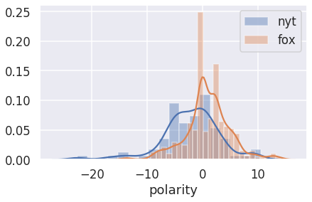

```python
nytweets = trump.loc[(trump['no_punc'].str.contains('nyt'))]
foxtweets = trump.loc[(trump['no_punc'].str.contains('fox'))]
sns.distplot(nytweets['polarity'], label = 'nyt')
sns.distplot(foxtweets['polarity'], label = 'fox')
plt.legend()
```

This shows us notice that the president appears to say more positive things about Fox than the New York Times.

## Engagement

Let's find the top 20 most retweeted words. While including only words that appear in at least 25 tweets.

```python
top_20 = trump.set_index('retweet_count')['no_punc'].str.split().reset_index()
top_20['no_punc'] = top_20['no_punc'].apply(lambda x: set(tuple(x))).rename(columns={0:'word'})
top_20['no_punc'] = top_20['no_punc'].apply(lambda x: ' '.join(x)).str.split(expand=True)
top_20 = top_20.rename(columns = {'no_punc' : 'word'})
thevals = top_20['word'].value_counts()
thevals = thevals[thevals > 25].index
top_20 = top_20.loc[top_20['word'].isin(thevals)].groupby('word')
top_20 = top_20.agg('sum').nlargest(20, 'retweet_count')
```

Here's a bar chart of the results:

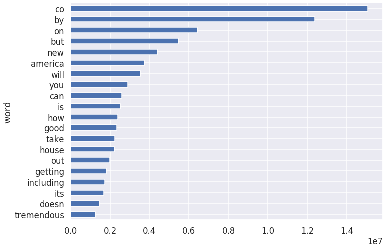

```python
top_20['retweet_count'].sort_values().plot.barh(figsize=(10, 8));
```

## An Interesting Plot

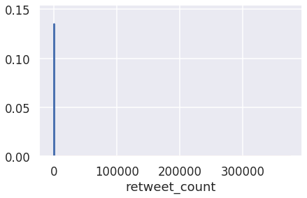

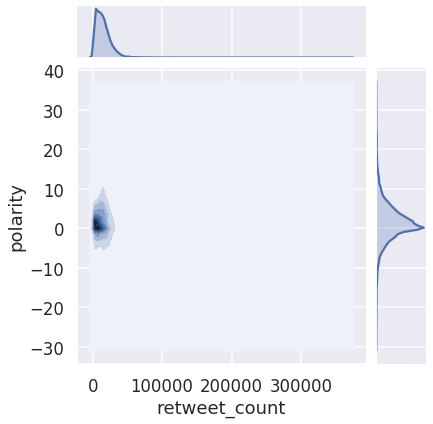

```python
x = sns.distplot(trump['polarity'])
x = sns.distplot(trump['retweet_count'])
sns.jointplot(x="retweet_count", y="polarity", data=trump, kind="kde")
```

## Thanks for checking out my project I hope you enjoyed it!